# EasyVisa Project

## Context:

Business communities in the United States are facing high demand for human resources, but one of the constant challenges is identifying and attracting the right talent, which is perhaps the most important element in remaining competitive. Companies in the United States look for hard-working, talented, and qualified individuals both locally as well as abroad.

The Immigration and Nationality Act (INA) of the US permits foreign workers to come to the United States to work on either a temporary or permanent basis. The act also protects US workers against adverse impacts on their wages or working conditions by ensuring US employers' compliance with statutory requirements when they hire foreign workers to fill workforce shortages. The immigration programs are administered by the Office of Foreign Labor Certification (OFLC).

OFLC processes job certification applications for employers seeking to bring foreign workers into the United States and grants certifications in those cases where employers can demonstrate that there are not sufficient US workers available to perform the work at wages that meet or exceed the wage paid for the occupation in the area of intended employment.

## Objective:

In FY 2016, the OFLC processed 775,979 employer applications for 1,699,957 positions for temporary and permanent labor certifications. This was a nine percent increase in the overall number of processed applications from the previous year. The process of reviewing every case is becoming a tedious task as the number of applicants is increasing every year.

The increasing number of applicants every year calls for a Machine Learning based solution that can help in shortlisting the candidates having higher chances of VISA approval. OFLC has hired your firm EasyVisa for data-driven solutions. You as a data scientist have to analyze the data provided and, with the help of a classification model:

- Facilitate the process of visa approvals.
- Recommend a suitable profile for the applicants for whom the visa should be certified or denied based on the drivers that significantly influence the case status.

## Data Description

The data contains the different attributes of the employee and the employer. The detailed data dictionary is given below.

- case_id: ID of each visa application
- continent: Information of continent the employee
- education_of_employee: Information of education of the employee
- has_job_experience: Does the employee has any job experience? Y= Yes; N = No
- requires_job_training: Does the employee require any job training? Y = Yes; N = No
- no_of_employees: Number of employees in the employer's company
- yr_of_estab: Year in which the employer's company was established
- region_of_employment: Information of foreign worker's intended region of employment in the US.
- prevailing_wage: Average wage paid to similarly employed workers in a specific occupation in the area of intended employment. The purpose of the prevailing wage is to ensure that the foreign worker is not underpaid compared to other workers offering the same or similar service in the same area of employment.
- unit_of_wage: Unit of prevailing wage. Values include Hourly, Weekly, Monthly, and Yearly.
- full_time_position: Is the position of work full-time? Y = Full Time Position; N = Part Time Position
- case_status: Flag indicating if the Visa was certified or denied

## Import Libraries

```python
#%load_ext nb_black

import warnings

warnings.filterwarnings("ignore")

import numpy as np
import pandas as pd

from sklearn.model_selection import train_test_split

import matplotlib.pyplot as plt
import seaborn as sns

# Removes the limit for the number of displayed columns
pd.set_option("display.max_columns", None)
# Sets the limit for the number of displayed rows
pd.set_option("display.max_rows", 100)

# Libraries different ensemble classifiers
from sklearn.ensemble import (
    BaggingClassifier,
    RandomForestClassifier,
    AdaBoostClassifier,
    GradientBoostingClassifier,
    StackingClassifier,)

from xgboost import XGBClassifier
from sklearn.tree import DecisionTreeClassifier

# Libraries to get different metric scores
from sklearn import metrics
from sklearn.metrics import (
    confusion_matrix,
    accuracy_score,
    precision_score,
    recall_score,
    f1_score,)

# To tune different models
from sklearn.model_selection import GridSearchCV
```

## Data Overview

- Observations
- Sanity checks

### Import the Dataset

```python
#Import dataset
data = pd.read_csv("EasyVisa.csv")
```

### Overview of the Dataset

```python
#View first 5 rows of the dataset
data.head()
```

|  | case_id | continent | education_of_employee | has_job_experience | requires_job_training | no_of_employees | yr_of_estab | region_of_employment | prevailing_wage | unit_of_wage | full_time_position | case_status |
| --- | --- | --- | --- | --- | --- | --- | --- | --- | --- | --- | --- | --- |
| 0 | EZYV01 | Asia | High School | N | N | 14513 | 2007 | West | 592.2029 | Hour | Y | Denied |
| 1 | EZYV02 | Asia | Master's | Y | N | 2412 | 2002 | Northeast | 83425.6500 | Year | Y | Certified |
| 2 | EZYV03 | Asia | Bachelor's | N | Y | 44444 | 2008 | West | 122996.8600 | Year | Y | Denied |
| 3 | EZYV04 | Asia | Bachelor's | N | N | 98 | 1897 | West | 83434.0300 | Year | Y | Denied |
| 4 | EZYV05 | Africa | Master's | Y | N | 1082 | 2005 | South | 149907.3900 | Year | Y | Certified |

```python
#View last 5 rows of the dataset
data.tail()
```

|  | case_id | continent | education_of_employee | has_job_experience | requires_job_training | no_of_employees | yr_of_estab | region_of_employment | prevailing_wage | unit_of_wage | full_time_position | case_status |
| --- | --- | --- | --- | --- | --- | --- | --- | --- | --- | --- | --- | --- |
| 25475 | EZYV25476 | Asia | Bachelor's | Y | Y | 2601 | 2008 | South | 77092.57 | Year | Y | Certified |
| 25476 | EZYV25477 | Asia | High School | Y | N | 3274 | 2006 | Northeast | 279174.79 | Year | Y | Certified |
| 25477 | EZYV25478 | Asia | Master's | Y | N | 1121 | 1910 | South | 146298.85 | Year | N | Certified |
| 25478 | EZYV25479 | Asia | Master's | Y | Y | 1918 | 1887 | West | 86154.77 | Year | Y | Certified |
| 25479 | EZYV25480 | Asia | Bachelor's | Y | N | 3195 | 1960 | Midwest | 70876.91 | Year | Y | Certified |

```python
#Shape of the dataset
data.shape
```

```
(25480, 12)
```

#### Observations

- The dataset has 25,480 rows and 12 columns

```python
#Check data types
data.info()
```

```
<class 'pandas.core.frame.DataFrame'>
RangeIndex: 25480 entries, 0 to 25479
Data columns (total 12 columns):
 #   Column                 Non-Null Count  Dtype
---  ------                 --------------  -----
 0   case_id                25480 non-null  object
 1   continent              25480 non-null  object
 2   education_of_employee  25480 non-null  object
 3   has_job_experience     25480 non-null  object
 4   requires_job_training  25480 non-null  object
 5   no_of_employees        25480 non-null  int64
 6   yr_of_estab            25480 non-null  int64
 7   region_of_employment   25480 non-null  object
 8   prevailing_wage        25480 non-null  float64
 9   unit_of_wage           25480 non-null  object
 10  full_time_position     25480 non-null  object
 11  case_status            25480 non-null  object
dtypes: float64(1), int64(2), object(9)
memory usage: 2.3+ MB
```

#### Observations

- 9 columns are of type object
  - These will need to be converted to numeric values for bagging and boosting analysis
- 3 columns are numeric

```python
#Check for duplicate values
data.duplicated().sum()
```

```
0
```

```python
#Check for missing values
data.isnull().sum()
```

```
case_id                  0
continent                0
education_of_employee    0
has_job_experience       0
requires_job_training    0
no_of_employees          0
yr_of_estab              0
region_of_employment     0
prevailing_wage          0
unit_of_wage             0
full_time_position       0
case_status              0
dtype: int64
```

```python
#Check for null values
data.isna().sum()
```

```
case_id                  0
continent                0
education_of_employee    0
has_job_experience       0
requires_job_training    0
no_of_employees          0
yr_of_estab              0
region_of_employment     0
prevailing_wage          0
unit_of_wage             0
full_time_position       0
case_status              0
dtype: int64
```

#### Observations

- No duplicate rows in the dataframe
- No missing or null values in the dataframe

```python
#Check number of unique observations
data.nunique(axis = 0)
```

```
case_id                  25480
continent                    6
education_of_employee        4
has_job_experience           2
requires_job_training        2
no_of_employees           7105
yr_of_estab                199
region_of_employment         5
prevailing_wage          25454
unit_of_wage                 4
full_time_position           2
case_status                  2
dtype: int64
```

#### Observations

- For case_id, there is a unique value for each observation
- case_id provides no explanatory power in predicting case_status, so it will be removed

```python
#Drop case_id
data.drop(['case_id'], axis=1, inplace=True)
data.head()
```

|  | continent | education_of_employee | has_job_experience | requires_job_training | no_of_employees | yr_of_estab | region_of_employment | prevailing_wage | unit_of_wage | full_time_position | case_status |
| --- | --- | --- | --- | --- | --- | --- | --- | --- | --- | --- | --- |
| 0 | Asia | High School | N | N | 14513 | 2007 | West | 592.2029 | Hour | Y | Denied |
| 1 | Asia | Master's | Y | N | 2412 | 2002 | Northeast | 83425.6500 | Year | Y | Certified |
| 2 | Asia | Bachelor's | N | Y | 44444 | 2008 | West | 122996.8600 | Year | Y | Denied |
| 3 | Asia | Bachelor's | N | N | 98 | 1897 | West | 83434.0300 | Year | Y | Denied |
| 4 | Africa | Master's | Y | N | 1082 | 2005 | South | 149907.3900 | Year | Y | Certified |

## Exploratory Data Analysis (EDA)

- EDA is an important part of any project involving data.
- It is important to investigate and understand the data better before building a model with it.
- A few questions have been mentioned below which will help you approach the analysis in the right manner and generate insights from the data.
- A thorough analysis of the data, in addition to the questions mentioned below, should be done.

**Leading Questions**:

1. Those with higher education may want to travel abroad for a well-paid job. Does education play a role in Visa certification?
2. How does the visa status vary across different continents?
3. Experienced professionals might look abroad for opportunities to improve their lifestyles and career development. Does work experience influence visa status?
4. In the United States, employees are paid at different intervals. Which pay unit is most likely to be certified for a visa?
5. The US government has established a prevailing wage to protect local talent and foreign workers. How does the visa status change with the prevailing wage?

```python
#Check the statistical summary of the data
data.describe(include = "all").T
```

|  | count | unique | top | freq | mean | std | min | 25% | 50% | 75% | max |
| --- | --- | --- | --- | --- | --- | --- | --- | --- | --- | --- | --- |
| continent | 25480 | 6 | Asia | 16861 | NaN | NaN | NaN | NaN | NaN | NaN | NaN |
| education_of_employee | 25480 | 4 | Bachelor's | 10234 | NaN | NaN | NaN | NaN | NaN | NaN | NaN |
| has_job_experience | 25480 | 2 | Y | 14802 | NaN | NaN | NaN | NaN | NaN | NaN | NaN |
| requires_job_training | 25480 | 2 | N | 22525 | NaN | NaN | NaN | NaN | NaN | NaN | NaN |
| no_of_employees | 25480.0 | NaN | NaN | NaN | 5667.04321 | 22877.928848 | -26.0 | 1022.0 | 2109.0 | 3504.0 | 602069.0 |
| yr_of_estab | 25480.0 | NaN | NaN | NaN | 1979.409929 | 42.366929 | 1800.0 | 1976.0 | 1997.0 | 2005.0 | 2016.0 |
| region_of_employment | 25480 | 5 | Northeast | 7195 | NaN | NaN | NaN | NaN | NaN | NaN | NaN |
| prevailing_wage | 25480.0 | NaN | NaN | NaN | 74455.814592 | 52815.942327 | 2.1367 | 34015.48 | 70308.21 | 107735.5125 | 319210.27 |
| unit_of_wage | 25480 | 4 | Year | 22962 | NaN | NaN | NaN | NaN | NaN | NaN | NaN |
| full_time_position | 25480 | 2 | Y | 22773 | NaN | NaN | NaN | NaN | NaN | NaN | NaN |
| case_status | 25480 | 2 | Certified | 17018 | NaN | NaN | NaN | NaN | NaN | NaN | NaN |

#### Observations

- continent, education_of_employee, has_job_experience, requires_job_training, region_of_employment, unit_of_wage, full_time_position, and case_status are of type object with 6 or fewer unique values for each
- Remaining fields are numeric
- no_of_employees has some negative values which is nonsensical
  - Convert these to positive values

```python
#Find number of observations with a negative value for no_of_employees
data.loc[data["no_of_employees"]<0].shape
```

```
(33, 11)
```

#### Observations

- 33 rows have a negative value for no_of_employees
- Convert these to positive values by applying absolute value

```python
#Absolute values for number of employees
data["no_of_employees"] = data["no_of_employees"].abs()

#Recheck the statistical summary of the data
data.describe(include = "all").T
```

|  | count | unique | top | freq | mean | std | min | 25% | 50% | 75% | max |
| --- | --- | --- | --- | --- | --- | --- | --- | --- | --- | --- | --- |
| continent | 25480 | 6 | Asia | 16861 | NaN | NaN | NaN | NaN | NaN | NaN | NaN |
| education_of_employee | 25480 | 4 | Bachelor's | 10234 | NaN | NaN | NaN | NaN | NaN | NaN | NaN |
| has_job_experience | 25480 | 2 | Y | 14802 | NaN | NaN | NaN | NaN | NaN | NaN | NaN |
| requires_job_training | 25480 | 2 | N | 22525 | NaN | NaN | NaN | NaN | NaN | NaN | NaN |
| no_of_employees | 25480.0 | NaN | NaN | NaN | 5667.089207 | 22877.917453 | 11.0 | 1022.0 | 2109.0 | 3504.0 | 602069.0 |
| yr_of_estab | 25480.0 | NaN | NaN | NaN | 1979.409929 | 42.366929 | 1800.0 | 1976.0 | 1997.0 | 2005.0 | 2016.0 |
| region_of_employment | 25480 | 5 | Northeast | 7195 | NaN | NaN | NaN | NaN | NaN | NaN | NaN |
| prevailing_wage | 25480.0 | NaN | NaN | NaN | 74455.814592 | 52815.942327 | 2.1367 | 34015.48 | 70308.21 | 107735.5125 | 319210.27 |
| unit_of_wage | 25480 | 4 | Year | 22962 | NaN | NaN | NaN | NaN | NaN | NaN | NaN |
| full_time_position | 25480 | 2 | Y | 22773 | NaN | NaN | NaN | NaN | NaN | NaN | NaN |
| case_status | 25480 | 2 | Certified | 17018 | NaN | NaN | NaN | NaN | NaN | NaN | NaN |

#### Observations

- The mimimum value for no_of_employees is now 11 so the issue of negative values for this variable is resolved

```python
#Check count of each unique category in each of the categorical variables
cat_col = list(data.select_dtypes("object").columns)

for column in cat_col:
    print(data[column].value_counts())
    print("-" * 50)
```

```
Asia             16861
Europe            3732
North America     3292
South America      852
Africa             551
Oceania            192
Name: continent, dtype: int64
--------------------------------------------------
Bachelor's     10234
Master's        9634
High School     3420
Doctorate       2192
Name: education_of_employee, dtype: int64
--------------------------------------------------
Y    14802
N    10678
Name: has_job_experience, dtype: int64
--------------------------------------------------
N    22525
Y     2955
Name: requires_job_training, dtype: int64
--------------------------------------------------
Northeast    7195
South        7017
West         6586
Midwest      4307
Island        375
Name: region_of_employment, dtype: int64
--------------------------------------------------
Year     22962
Hour      2157
Week       272
Month       89
Name: unit_of_wage, dtype: int64
--------------------------------------------------
Y    22773
N     2707
Name: full_time_position, dtype: int64
--------------------------------------------------
Certified    17018
Denied        8462
Name: case_status, dtype: int64
--------------------------------------------------
```

#### Convert the eight object columns to category

```python
for feature in data.columns:
    if data[feature].dtype == 'object':
        data[feature] = pd.Categorical(data[feature])
```

```python
#Check data types
data.info()
```

```
<class 'pandas.core.frame.DataFrame'>
RangeIndex: 25480 entries, 0 to 25479
Data columns (total 11 columns):
 #   Column                 Non-Null Count  Dtype
---  ------                 --------------  -----
 0   continent              25480 non-null  category
 1   education_of_employee  25480 non-null  category
 2   has_job_experience     25480 non-null  category
 3   requires_job_training  25480 non-null  category
 4   no_of_employees        25480 non-null  int64
 5   yr_of_estab            25480 non-null  int64
 6   region_of_employment   25480 non-null  category
 7   prevailing_wage        25480 non-null  float64
 8   unit_of_wage           25480 non-null  category
 9   full_time_position     25480 non-null  category
 10  case_status            25480 non-null  category
dtypes: category(8), float64(1), int64(2)
memory usage: 797.7 KB
```

## Univariate Analysis

```python
#Function to plot boxplot and histogram on the same scale

def histogram_boxplot(data, feature, figsize=(15, 10), kde=False, bins=None):
    """
    Boxplot and histogram combined

    data: dataframe
    feature: dataframe column
    figsize: size of figure (default (15,10))
    kde: whether to show the density curve (default False)
    bins: number of bins for histogram (default None)
    """
    f2, (ax_box2, ax_hist2) = plt.subplots(
        nrows=2,  # Number of rows of the subplot grid= 2
        sharex=True,  # x-axis will be shared among all subplots
        gridspec_kw={"height_ratios": (0.25, 0.75)},
        figsize=figsize,
    )  # creating the 2 subplots
    sns.boxplot(
        data=data, x=feature, ax=ax_box2, showmeans=True, color="violet"
    )  # boxplot will be created and a triangle will indicate the mean value of the column
    sns.histplot(
        data=data, x=feature, kde=kde, ax=ax_hist2, bins=bins
    ) if bins else sns.histplot(
        data=data, x=feature, kde=kde, ax=ax_hist2
    )  # For histogram
    ax_hist2.axvline(
        data[feature].mean(), color="green", linestyle="--"
    )  # Add mean to the histogram
    ax_hist2.axvline(
        data[feature].median(), color="black", linestyle="-"
    )  # Add median to the histogram
```

```python
#Define function to create labeled barplots

def labeled_barplot(data, feature, perc=False, n=None):
    """
    Barplot with percentage at the top

    data: dataframe
    feature: dataframe column
    perc: whether to display percentages instead of count (default is False)
    n: displays the top n category levels (default is None, i.e., display all levels)
    """

    total = len(data[feature])  # length of the column
    count = data[feature].nunique()
    if n is None:
        plt.figure(figsize=(count + 2, 6))
    else:
        plt.figure(figsize=(n + 2, 6))

    plt.xticks(rotation=90, fontsize=15)
    ax = sns.countplot(
        data=data,
        x=feature,
        palette="Paired",
        order=data[feature].value_counts().index[:n],
    )

    for p in ax.patches:
        if perc == True:
            label = "{:.1f}%".format(
                100 * p.get_height() / total
            )  # percentage of each class of the category
        else:
            label = p.get_height()  # count of each level of the category

        x = p.get_x() + p.get_width() / 2  # width of the plot
        y = p.get_height()  # height of the plot

        ax.annotate(
            label,
            (x, y),
            ha="center",
            va="center",
            size=12,
            xytext=(0, 5),
            textcoords="offset points",
        )  # annotate the percentage

    plt.show()  # show the plot
```

#### Number of Employees

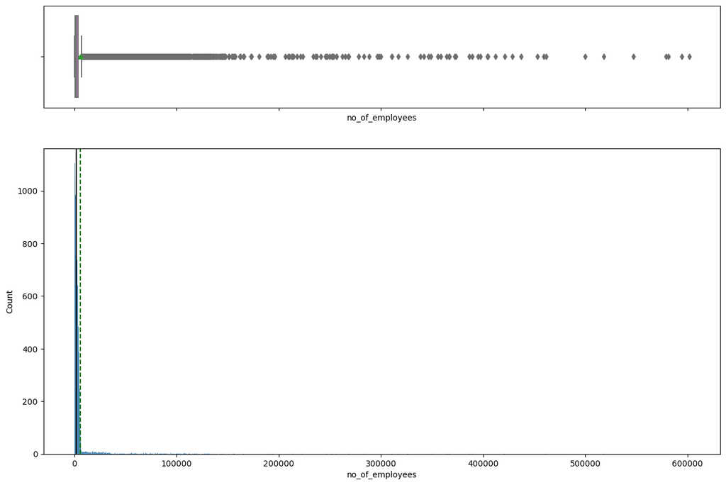

```python
histogram_boxplot(data, "no_of_employees")
```

```python
data[data["no_of_employees"] < 5000].value_counts().sum()
```

```
22840
```

#### Observations

- 22,840 applications out of 25,480 have fewer than 5,000 employees, or 89.6%
- Minimum number of employees is 11 and maximum number of employees is 602,069

#### Year of Establishment

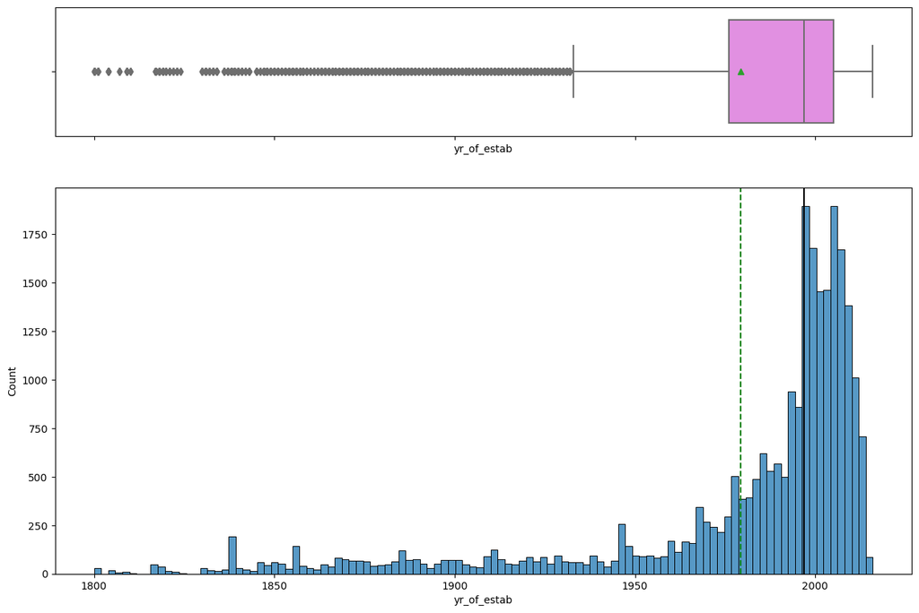

```python
histogram_boxplot(data, "yr_of_estab")
```

#### Observations

- The median year of establishment is 1997
- The minimum year of establishment is 1800
- The maximum year of establishment is 2016
- This variable will later be converted to age by taking the current year (2016) and subtracting the year of establishment

#### Prevailing Wage

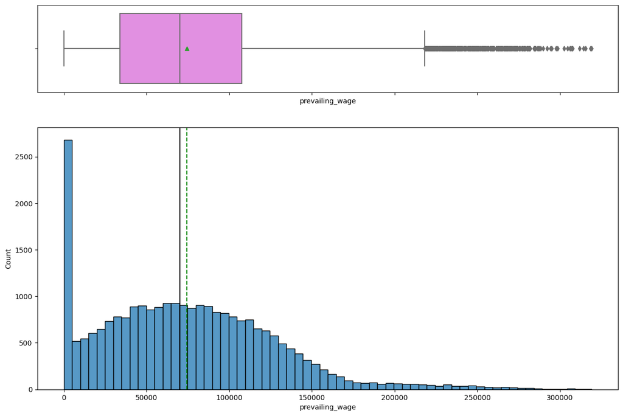

```python
histogram_boxplot(data, "prevailing_wage")
```

```python
#Find number of observations with a prevailing wage less than 100
data[data["prevailing_wage"] < 100].value_counts().sum()
```

```
176
```

```python
#Count by unit_of_wage for prevailing_wage less than 100
data.loc[data["prevailing_wage"] < 100, "unit_of_wage"].value_counts()
```

```
Hour     176
Month      0
Week       0
Year       0
Name: unit_of_wage, dtype: int64
```

#### Observations

- 176 values of prevailing_wage are under 100
- Since prevailing_wage can be hourly, monthly, weekly, or yearly, the box plot and histogram of prevailing wage are difficult to interpret
- Prevailing wage may need to be treated differently depending on the unit of wage for analysis

#### Education

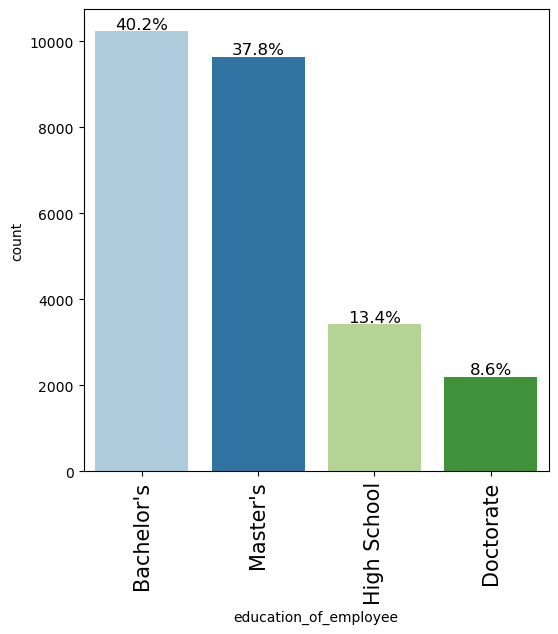

```python
labeled_barplot(data, "education_of_employee", perc=True)
```

#### Observations

- 40.2% of employees have a bachelor's degree
- 37.8% of employees have a master's degree
- 13.4% of employees have a high school education
- 8.6% of employees have a doctoral degree

#### Continent

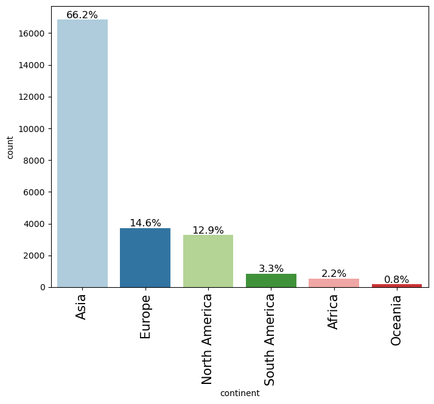

```python
labeled_barplot(data, "continent", perc=True)
```

#### Observations

- 66.2% of employees considered for certification are from Asia
  - 14.6% are from Europe
  - 12.9% are from North America
- 3.3%, 2.2% and 0.8% of employees considered are from South America, Africa, and Oceania, respectively

#### Job Experience

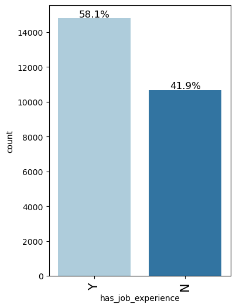

```python
labeled_barplot(data, "has_job_experience", perc = True)
```

#### Observations

- 58.1% of employees have job experience
- 41.9% of employess do not have job experience

#### Job Training Required

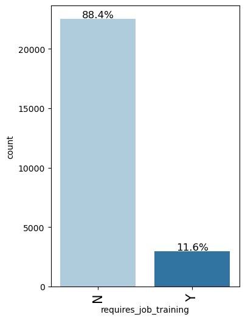

```python
labeled_barplot(data, "requires_job_training", perc = True)
```

#### Observations

- 88.4% of employees do not require job training
- 11.6% of employees require job training

#### Region of Employment in the US

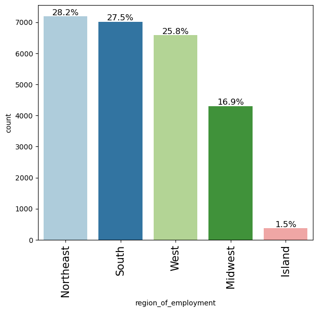

```python
labeled_barplot(data, "region_of_employment", perc = True)
```

#### Observations

- 28.2% of employees are in the Northeast region
- 27.5% of employees are in the South region
- 25.8% of employees are in the West region
- 16.9% of employees are in the Midwest region
- 1.5% of employee are in the Island region

#### Unit of Wage

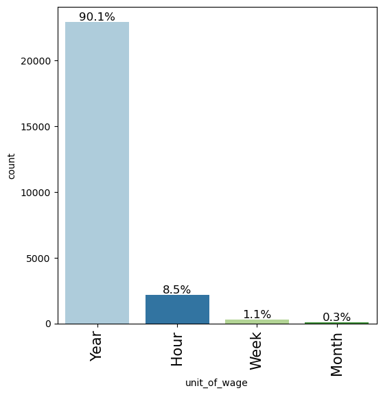

```python
labeled_barplot(data, "unit_of_wage", perc = True)
```

#### Observations

- 90.1% of observations have yearly wages
- 8.5% of observations have hourly wages
- 1.1% and 0.3% of observations have weekly wages and monthly wages, respectively

#### Case Status

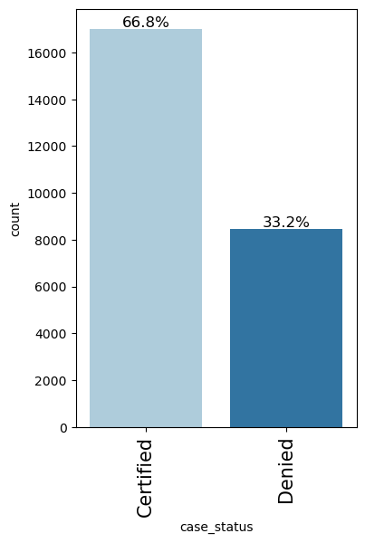

```python
labeled_barplot(data, "case_status", perc = True)
```

#### Observations

- 66.8% of cases are certified
- 33.2% of cases are denied

## Bivariate Analysis

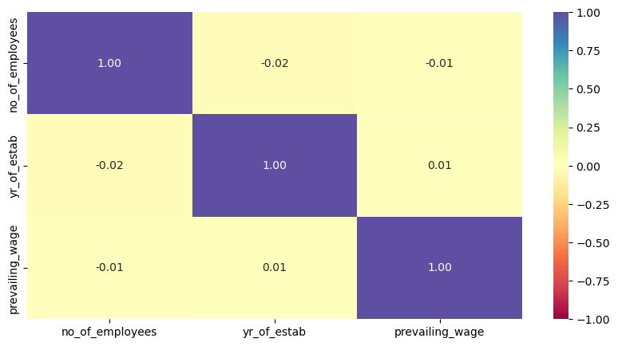

```python
# Find the correlations between the numeric values
cols_list = data.select_dtypes(include=np.number).columns.tolist()

plt.figure(figsize=(10, 5))
sns.heatmap(
    data[cols_list].corr(), annot=True, vmin=-1, vmax=1, fmt=".2f", cmap="Spectral"
)
plt.show()
```

#### Observations

- There is essentially no correlation between any of the three numeric variables

```python
# Define function to plot distributions relative to target

def distribution_plot_wrt_target(data, predictor, target):

    fig, axs = plt.subplots(2, 2, figsize=(12, 10))

    target_uniq = data[target].unique()

    axs[0, 0].set_title("Distribution of target for target=" + str(target_uniq[0]))
    sns.histplot(
        data=data[data[target] == target_uniq[0]],
        x=predictor,
        kde=True,
        ax=axs[0, 0],
        color="teal",
        stat="density",
    )

    axs[0, 1].set_title("Distribution of target for target=" + str(target_uniq[1]))
    sns.histplot(
        data=data[data[target] == target_uniq[1]],
        x=predictor,
        kde=True,
        ax=axs[0, 1],
        color="orange",
        stat="density",
    )

    axs[1, 0].set_title("Boxplot w.r.t target")
    sns.boxplot(data=data, x=target, y=predictor, ax=axs[1, 0], palette="gist_rainbow")

    axs[1, 1].set_title("Boxplot (without outliers) w.r.t target")
    sns.boxplot(
        data=data,
        x=target,
        y=predictor,
        ax=axs[1, 1],
        showfliers=False,
        palette="gist_rainbow",
    )

    plt.tight_layout()
    plt.show()
```

```python
# Define function to create bar plot relative to target

def stacked_barplot(data, predictor, target):

    count = data[predictor].nunique()
    sorter = data[target].value_counts().index[-1]
    tab1 = pd.crosstab(data[predictor], data[target], margins=True).sort_values(
        by=sorter, ascending=False
    )
    print(tab1)
    print("-" * 120)
    tab = pd.crosstab(data[predictor], data[target], normalize="index").sort_values(
        by=sorter, ascending=False
    )
    tab.plot(kind="bar", stacked=True, figsize=(count + 5, 5))
    plt.legend(
        loc="lower left", frameon=False,
    )
    plt.legend(loc="upper left", bbox_to_anchor=(1, 1))
    plt.show()
```

#### 1. Those with higher education may want to travel abroad for a well-paid job. Does education play a role in Visa certification?

```
case_status            Certified  Denied    All
education_of_employee
All                        17018    8462  25480
Bachelor's                  6367    3867  10234
High School                 1164    2256   3420
Master's                    7575    2059   9634
Doctorate                   1912     280   2192
------------------------------------------------------------------------------------------------------------------------
```

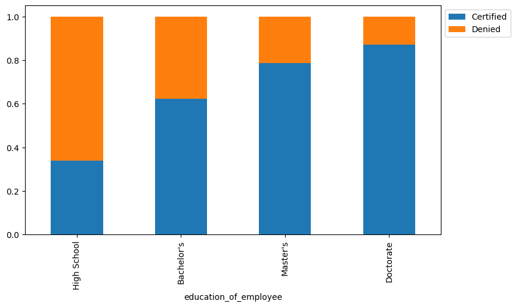

```python
stacked_barplot(data, "education_of_employee", "case_status")
```

#### Observations

- Overall, higher education levels relate to higher rates of certification monotonically
- For high school education, 34.0% are certified
- For bachelor's degree, 62.2% are certified
- For master's degree, 78.6% are certified
- For doctorate degree, 87.2% are certified

#### 2. How does the visa status vary across different continents?

```
case_status    Certified  Denied    All
continent
All                17018    8462  25480
Asia               11012    5849  16861
North America       2037    1255   3292
Europe              2957     775   3732
South America        493     359    852
Africa               397     154    551
Oceania              122      70    192
------------------------------------------------------------------------------------------------------------------------
```

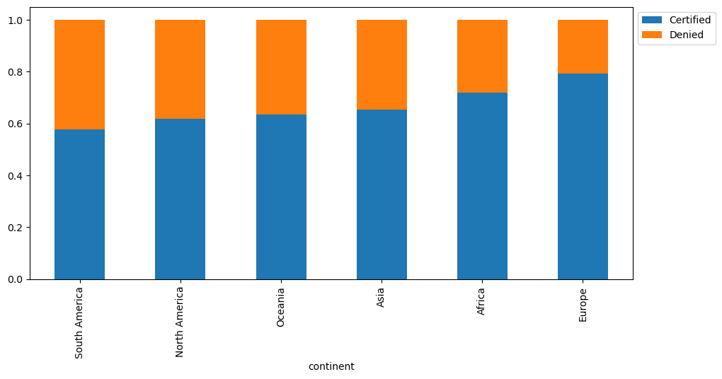

```python
stacked_barplot(data, "continent", "case_status")
```

#### Observations

- Europe has the highest certification rate at 79.2%
- Africa has the second highest certification rate at 72.1%
- Asia, Oceania, North America, and South America have certification rates of 65.3%, 63.5%, 61.9%, and 57.9%, respectively

#### 3. Experienced professionals might look abroad for opportunities to improve their lifestyles and career development. Does work experience influence visa status?

```
case_status         Certified  Denied    All
has_job_experience
All                     17018    8462  25480
N                        5994    4684  10678
Y                       11024    3778  14802
------------------------------------------------------------------------------------------------------------------------
```

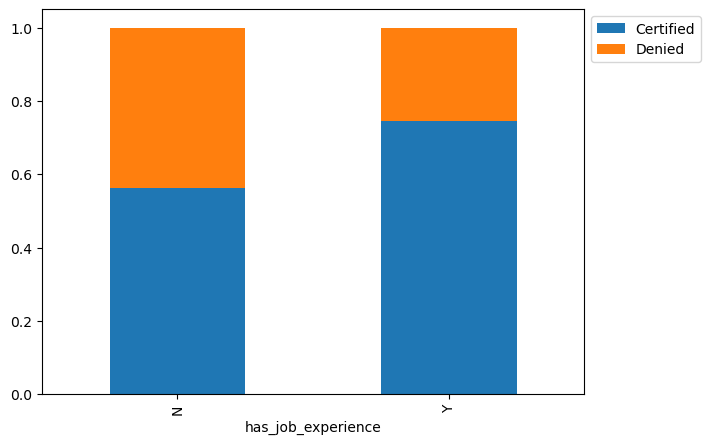

```python
stacked_barplot(data, "has_job_experience", "case_status")
```

#### Observations

- Employees with work experience have a certification rate of 74.5%
- Employees without work experience have a certification rate of 56.1%

#### 4. In the United States, employees are paid at different intervals. Which pay unit is most likely to be certified for a visa?

```
case_status   Certified  Denied    All
unit_of_wage
All               17018    8462  25480
Year              16047    6915  22962
Hour                747    1410   2157
Week                169     103    272
Month                55      34     89
------------------------------------------------------------------------------------------------------------------------
```

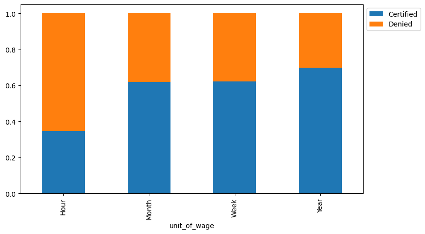

```python
stacked_barplot(data, "unit_of_wage", "case_status")
```

#### Observations

- Employees with salary stated as yearly have a certification rate of 69.9%
- Employees with salary stated as weekly have a certification rate of 62.1%
- Employees with salary stated as monthly have a certification rate of 61.8%
- Employees with salary stated as hourly have a certification rate of 34.6%

#### 5. The US government has established a prevailing wage to protect local talent and foreign workers. How does the visa status change with the prevailing wage?

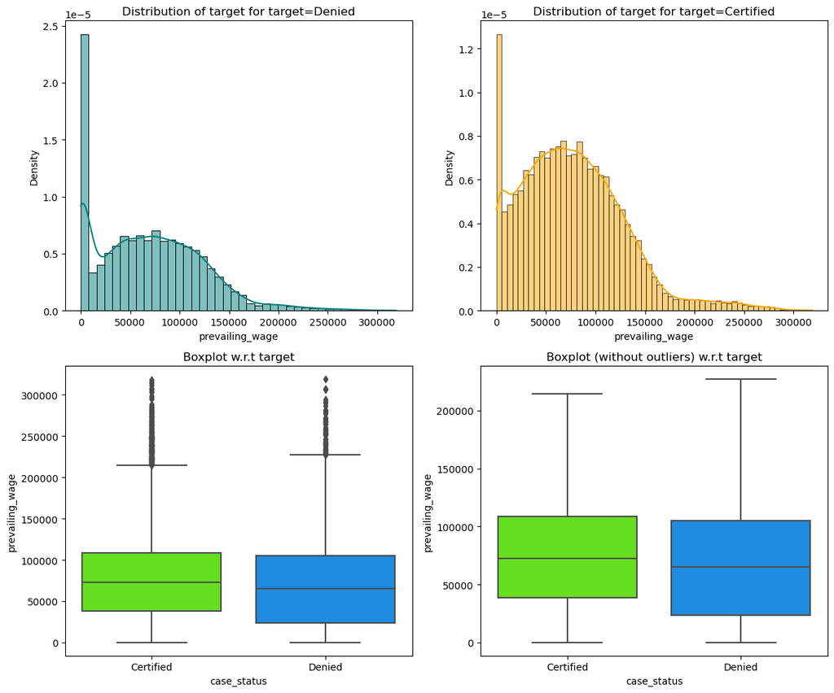

```python
distribution_plot_wrt_target(data, "prevailing_wage", "case_status")
```

#### Observations

- Certified cases have a slightly higher median prevailing wage than cases that are denied, but the difference is not large
- There are a number of outliers on the right side of the distribution reflecting higher prevailing wages
- The wages may need to be standardized to an hourly equivalent based on reasonable assumptions in the case of part-time employees

#### Prevailing wage across regions

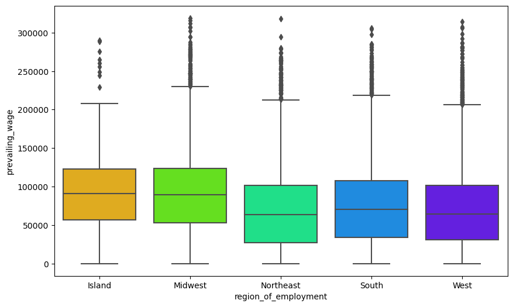

```python
plt.figure(figsize=(10, 6))
sns.boxplot(data=data, x="region_of_employment", y="prevailing_wage", palette="gist_rainbow")
plt.show()
```

#### Observations

- Median prevailing wage is highest in the Island region and is second highest in the Midwest region
- Prevailing wage has a number of outliers on the right side of the distribution

#### Educational requirements across regions

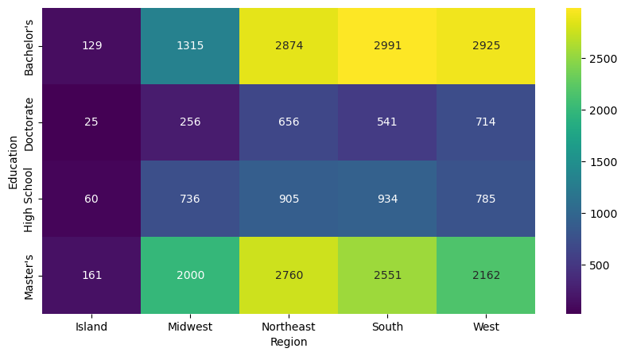

```python
plt.figure(figsize=(10, 5))
sns.heatmap(pd.crosstab(data.education_of_employee, data.region_of_employment),
    annot=True,
    fmt="g",
    cmap="viridis"
)

plt.ylabel("Education")
plt.xlabel("Region")
plt.show()
```

```
case_status           Certified  Denied    All
region_of_employment
All                       17018    8462  25480
Northeast                  4526    2669   7195
West                       4100    2486   6586
South                      4913    2104   7017
Midwest                    3253    1054   4307
Island                      226     149    375
------------------------------------------------------------------------------------------------------------------------
```

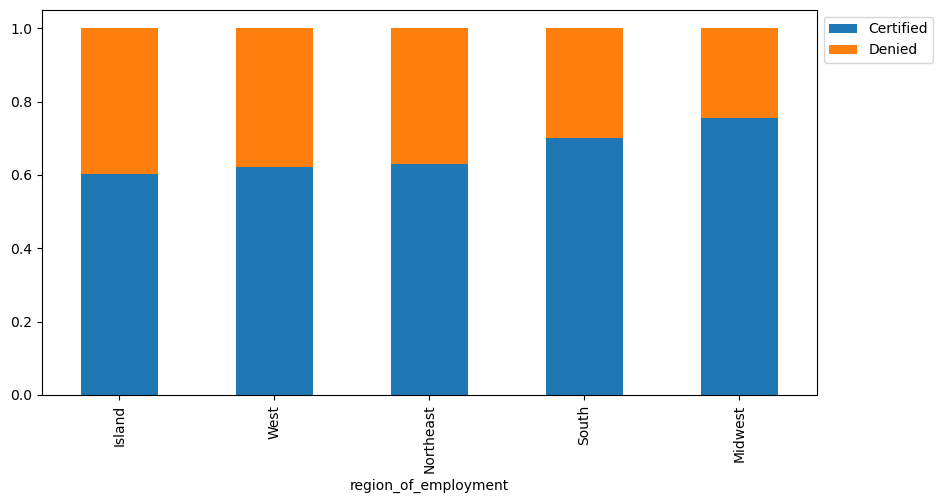

```python
stacked_barplot(data, "region_of_employment", "case_status")
```

#### Observations

- The Midwest region has 1,315 applications with the employee having a bachelor's degree (30.5%)
  - The region had 2,000 applications with the employee having a master's degree (46.4%)
  - The region also had the highest certification rate at 75.5%
- The Northeast region has 2,874 applications with the employee having a bachelor's degree (39.9%)
  - The region had 2,760 applications with the employee having a master's degree (38.4%)
- The South region has 2,991 applications with the employee having a bachelor's degree (42.6%)
  - The region had 2,551 applications with the employee having a master's degree (36.4%)
  - The region also had the second highest certification rate at 70.0%
- The West region has 2,925 applications with the employee having a bachelor's degree (44.4%)
  - The region had 2,162 applications with the employee having a master's degree (32.8%)

#### Work experience and training requirements

```
requires_job_training      N     Y    All
has_job_experience
All                    22525  2955  25480
N                       8988  1690  10678
Y                      13537  1265  14802
------------------------------------------------------------------------------------------------------------------------
```

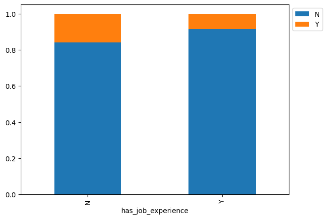

```python
stacked_barplot(data, "has_job_experience", "requires_job_training")
```

#### Observations

- Employees with job experience only require training 8.5% of the time
- Employees without job experience require training 15.8% of the time

## Data Preprocessing

- Missing value treatment
  - There are no missing values, so no treatment is needed
- Feature engineering
  - Features will need to be changed from categorical to numeric, along with other adjustments
- Outlier detection and treatment
  - Outliers will likely be retained so as not to lose information contained in these variables
- Preparing data for modeling
  - Data will need to be prepared for modeling
  - Most of this preparation will be done through feature engineering
- Any other preprocessing steps

#### Outlier check

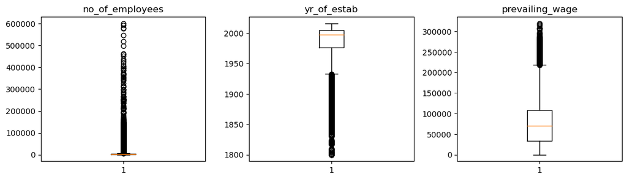

```python
# outlier detection using boxplot
numeric_columns = data.select_dtypes(include=np.number).columns.tolist()


plt.figure(figsize=(15, 12))

for i, variable in enumerate(numeric_columns):
    plt.subplot(4, 4, i + 1)
    plt.boxplot(data[variable], whis=1.5)
    plt.tight_layout()
    plt.title(variable)

plt.show()
```

#### Observations

- All of three of the numeric variables contain valuable information, so outliers will be kept in the data
- Year of establishment will be converted to age
- Prevailing wage will be adjusted to an hourly basis for all employees

```python
#Check data types
data.info()
```

```
<class 'pandas.core.frame.DataFrame'>
RangeIndex: 25480 entries, 0 to 25479
Data columns (total 11 columns):
 #   Column                 Non-Null Count  Dtype
---  ------                 --------------  -----
 0   continent              25480 non-null  category
 1   education_of_employee  25480 non-null  category
 2   has_job_experience     25480 non-null  category
 3   requires_job_training  25480 non-null  category
 4   no_of_employees        25480 non-null  int64
 5   yr_of_estab            25480 non-null  int64
 6   region_of_employment   25480 non-null  category
 7   prevailing_wage        25480 non-null  float64
 8   unit_of_wage           25480 non-null  category
 9   full_time_position     25480 non-null  category
 10  case_status            25480 non-null  category
dtypes: category(8), float64(1), int64(2)
memory usage: 797.7 KB
```

#### Observations

- Create new variables:
  - age for the age of the company
  - hourly_wage to standardize wages

```python
#Create new variable age for age of the company
data['age'] = 2016 - data['yr_of_estab']
```

```python
#Drop yr_of_estab
data.drop(['yr_of_estab'], axis=1, inplace=True)
data.head()
```

|  | continent | education_of_employee | has_job_experience | requires_job_training | no_of_employees | region_of_employment | prevailing_wage | unit_of_wage | full_time_position | case_status | age |
| --- | --- | --- | --- | --- | --- | --- | --- | --- | --- | --- | --- |
| 0 | Asia | High School | N | N | 14513 | West | 592.2029 | Hour | Y | Denied | 9 |
| 1 | Asia | Master's | Y | N | 2412 | Northeast | 83425.6500 | Year | Y | Certified | 14 |
| 2 | Asia | Bachelor's | N | Y | 44444 | West | 122996.8600 | Year | Y | Denied | 8 |
| 3 | Asia | Bachelor's | N | N | 98 | West | 83434.0300 | Year | Y | Denied | 119 |
| 4 | Africa | Master's | Y | N | 1082 | South | 149907.3900 | Year | Y | Certified | 11 |

#### Standardize prevailing wage

- Convert into an hourly wage
- First check the prevailing wage by unit of wage

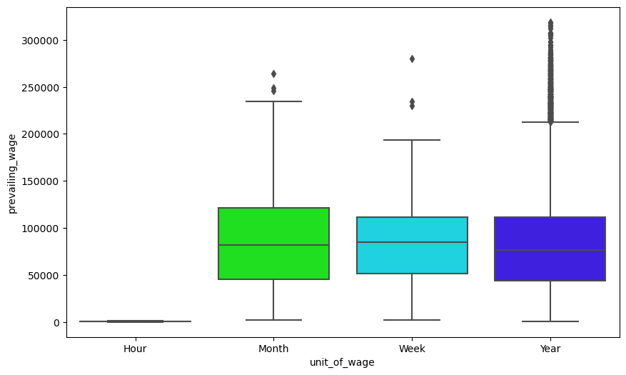

```python
plt.figure(figsize=(10, 6))
sns.boxplot(data=data, x="unit_of_wage", y="prevailing_wage", palette="gist_rainbow")
plt.show()
```

#### Observations

- For unit_of_wage equal to Hour, it appears these observations are stated hourly, as expected
- For unit_of_wage equal to Year, it appears these observations are stated yearly, as expected
- For unit_of_wage equal to Week or Month, it appears that these are actually stated on an annual basis
  - Those with unit_of_wage equal to Week or Month will be converted to an hourly basis as the prevailing wage is stated on an annual basis

```python
#Create hrly_prevailing_wage variable

#For full-time employees, assume 2,000 hours in a year, 160 hours in a month, and 40 hours in a week
#For part-time employees, assume 1,250 hours in a year, 100 hours in a month, and 25 hours in a week

def convert(data):
    if (data['unit_of_wage'] == 'Year') and (data['full_time_position'] == 'Y'):
        return data['prevailing_wage'] / 2000
    elif (data['unit_of_wage'] == 'Month') and (data['full_time_position'] == 'Y'):
        return data['prevailing_wage'] / 2000
    elif (data['unit_of_wage'] == 'Week') and (data['full_time_position'] == 'Y'):
        return data['prevailing_wage'] / 2000
    elif (data['unit_of_wage'] == 'Year') and (data['full_time_position'] == 'N'):
        return data['prevailing_wage'] / 1250
    elif (data['unit_of_wage'] == 'Month') and (data['full_time_position'] == 'N'):
        return data['prevailing_wage'] / 1250
    elif (data['unit_of_wage'] == 'Week') and (data['full_time_position'] == 'N'):
        return data['prevailing_wage'] / 1250
    elif (data['unit_of_wage'] == 'Hour'):
        return data['prevailing_wage']

data['hrly_prevailing_wage'] = data.apply(convert, axis =1)
```

```python
#Drop prevailing_wage and unit_of_wage
data.drop(['prevailing_wage', 'unit_of_wage'], axis=1, inplace=True)
data.head()
```

|  | continent | education_of_employee | has_job_experience | requires_job_training | no_of_employees | region_of_employment | full_time_position | case_status | age | hrly_prevailing_wage |
| --- | --- | --- | --- | --- | --- | --- | --- | --- | --- | --- |
| 0 | Asia | High School | N | N | 14513 | West | Y | Denied | 9 | 592.202900 |
| 1 | Asia | Master's | Y | N | 2412 | Northeast | Y | Certified | 14 | 41.712825 |
| 2 | Asia | Bachelor's | N | Y | 44444 | West | Y | Denied | 8 | 61.498430 |
| 3 | Asia | Bachelor's | N | N | 98 | West | Y | Denied | 119 | 41.717015 |
| 4 | Africa | Master's | Y | N | 1082 | South | Y | Certified | 11 | 74.953695 |

## Create dummy variables

- Use one-hot encoding for continent and region_of_employment
- Assign ranked values for education_of_employee
- For has_job_experience, requires_job_training, full_time_position, assign a value of 1 if 'Y' and 0 if 'N'
- For case_status, assign a value of 1 if 'Certified' and 0 if 'Denied'

```python
#Create dummy variable for case_status
data['case_status'] = np.where(data['case_status'] == "Certified", 1, 0)

#Create dummy variable for has_job_experience
data['has_job_experience'] = np.where(data['has_job_experience'] == "Y", 1, 0)

#Create dummy variable for requires_job_training
data['requires_job_training'] = np.where(data['requires_job_training'] == "Y", 1, 0)

#Create dummy varaible for full_time_position
data['full_time_position'] = np.where(data['full_time_position'] == "Y", 1, 0)

#Create dummy variables for continent and region_of_employment
data = pd.get_dummies(data, columns=["continent", "region_of_employment"], drop_first = True)

data.head()
```

|  | education_of_employee | has_job_experience | requires_job_training | no_of_employees | full_time_position | case_status | age | hrly_prevailing_wage | continent_Asia | continent_Europe | continent_North America | continent_Oceania | continent_South America | region_of_employment_Midwest | region_of_employment_Northeast | region_of_employment_South | region_of_employment_West |
| --- | --- | --- | --- | --- | --- | --- | --- | --- | --- | --- | --- | --- | --- | --- | --- | --- | --- |
| 0 | High School | 0 | 0 | 14513 | 1 | 0 | 9 | 592.202900 | 1 | 0 | 0 | 0 | 0 | 0 | 0 | 0 | 1 |
| 1 | Master's | 1 | 0 | 2412 | 1 | 1 | 14 | 41.712825 | 1 | 0 | 0 | 0 | 0 | 0 | 1 | 0 | 0 |
| 2 | Bachelor's | 0 | 1 | 44444 | 1 | 0 | 8 | 61.498430 | 1 | 0 | 0 | 0 | 0 | 0 | 0 | 0 | 1 |
| 3 | Bachelor's | 0 | 0 | 98 | 1 | 0 | 119 | 41.717015 | 1 | 0 | 0 | 0 | 0 | 0 | 0 | 0 | 1 |
| 4 | Master's | 1 | 0 | 1082 | 1 | 1 | 11 | 74.953695 | 0 | 0 | 0 | 0 | 0 | 0 | 0 | 1 | 0 |

```python
#Assigned ranked values for education_of_employee
replaceStruct = {"education_of_employee": {"High School": 1, "Bachelor's": 2 ,"Master's": 3 ,"Doctorate": 4}}

data=data.replace(replaceStruct)

data.head()
```

|  | education_of_employee | has_job_experience | requires_job_training | no_of_employees | full_time_position | case_status | age | hrly_prevailing_wage | continent_Asia | continent_Europe | continent_North America | continent_Oceania | continent_South America | region_of_employment_Midwest | region_of_employment_Northeast | region_of_employment_South | region_of_employment_West |
| --- | --- | --- | --- | --- | --- | --- | --- | --- | --- | --- | --- | --- | --- | --- | --- | --- | --- |
| 0 | 1 | 0 | 0 | 14513 | 1 | 0 | 9 | 592.202900 | 1 | 0 | 0 | 0 | 0 | 0 | 0 | 0 | 1 |
| 1 | 3 | 1 | 0 | 2412 | 1 | 1 | 14 | 41.712825 | 1 | 0 | 0 | 0 | 0 | 0 | 1 | 0 | 0 |
| 2 | 2 | 0 | 1 | 44444 | 1 | 0 | 8 | 61.498430 | 1 | 0 | 0 | 0 | 0 | 0 | 0 | 0 | 1 |
| 3 | 2 | 0 | 0 | 98 | 1 | 0 | 119 | 41.717015 | 1 | 0 | 0 | 0 | 0 | 0 | 0 | 0 | 1 |
| 4 | 3 | 1 | 0 | 1082 | 1 | 1 | 11 | 74.953695 | 0 | 0 | 0 | 0 | 0 | 0 | 0 | 1 | 0 |

```python
data.info()
```

```
<class 'pandas.core.frame.DataFrame'>
RangeIndex: 25480 entries, 0 to 25479
Data columns (total 17 columns):
 #   Column                          Non-Null Count  Dtype
---  ------                          --------------  -----
 0   education_of_employee           25480 non-null  category
 1   has_job_experience              25480 non-null  int32
 2   requires_job_training           25480 non-null  int32
 3   no_of_employees                 25480 non-null  int64
 4   full_time_position              25480 non-null  int32
 5   case_status                     25480 non-null  int32
 6   age                             25480 non-null  int64
 7   hrly_prevailing_wage            25480 non-null  float64
 8   continent_Asia                  25480 non-null  uint8
 9   continent_Europe                25480 non-null  uint8
 10  continent_North America         25480 non-null  uint8
 11  continent_Oceania               25480 non-null  uint8
 12  continent_South America         25480 non-null  uint8
 13  region_of_employment_Midwest    25480 non-null  uint8
 14  region_of_employment_Northeast  25480 non-null  uint8
 15  region_of_employment_South      25480 non-null  uint8
 16  region_of_employment_West       25480 non-null  uint8
dtypes: category(1), float64(1), int32(4), int64(2), uint8(9)
memory usage: 1.2 MB
```

#### Observations

- education_of_employee is of type category and should be converted to numeric

```python
data = data.assign(education_of_employee = pd.to_numeric(data['education_of_employee']))

data.head()
```

|  | education_of_employee | has_job_experience | requires_job_training | no_of_employees | full_time_position | case_status | age | hrly_prevailing_wage | continent_Asia | continent_Europe | continent_North America | continent_Oceania | continent_South America | region_of_employment_Midwest | region_of_employment_Northeast | region_of_employment_South | region_of_employment_West |
| --- | --- | --- | --- | --- | --- | --- | --- | --- | --- | --- | --- | --- | --- | --- | --- | --- | --- |
| 0 | 1 | 0 | 0 | 14513 | 1 | 0 | 9 | 592.202900 | 1 | 0 | 0 | 0 | 0 | 0 | 0 | 0 | 1 |
| 1 | 3 | 1 | 0 | 2412 | 1 | 1 | 14 | 41.712825 | 1 | 0 | 0 | 0 | 0 | 0 | 1 | 0 | 0 |
| 2 | 2 | 0 | 1 | 44444 | 1 | 0 | 8 | 61.498430 | 1 | 0 | 0 | 0 | 0 | 0 | 0 | 0 | 1 |
| 3 | 2 | 0 | 0 | 98 | 1 | 0 | 119 | 41.717015 | 1 | 0 | 0 | 0 | 0 | 0 | 0 | 0 | 1 |
| 4 | 3 | 1 | 0 | 1082 | 1 | 1 | 11 | 74.953695 | 0 | 0 | 0 | 0 | 0 | 0 | 0 | 1 | 0 |

```python
data.info()
```

```
<class 'pandas.core.frame.DataFrame'>
RangeIndex: 25480 entries, 0 to 25479
Data columns (total 17 columns):
 #   Column                          Non-Null Count  Dtype
---  ------                          --------------  -----
 0   education_of_employee           25480 non-null  int64
 1   has_job_experience              25480 non-null  int32
 2   requires_job_training           25480 non-null  int32
 3   no_of_employees                 25480 non-null  int64
 4   full_time_position              25480 non-null  int32
 5   case_status                     25480 non-null  int32
 6   age                             25480 non-null  int64
 7   hrly_prevailing_wage            25480 non-null  float64
 8   continent_Asia                  25480 non-null  uint8
 9   continent_Europe                25480 non-null  uint8
 10  continent_North America         25480 non-null  uint8
 11  continent_Oceania               25480 non-null  uint8
 12  continent_South America         25480 non-null  uint8
 13  region_of_employment_Midwest    25480 non-null  uint8
 14  region_of_employment_Northeast  25480 non-null  uint8
 15  region_of_employment_South      25480 non-null  uint8
 16  region_of_employment_West       25480 non-null  uint8
dtypes: float64(1), int32(4), int64(3), uint8(9)
memory usage: 1.4 MB
```

#### Conclusions

- All variables are now numeric
- All categorical variables have been transformed into dummy variables
- age is a new variable reflecting age of the company
- hrly_prevailing_wage takes the place of prevailing_wage and unit of wage
  - hrly_prevailing_wage is standardized into an hourly equivalent

## EDA

- It is a good idea to explore the data once again after manipulating it.

### Univariate Analysis

- The changes since the initial univariate analysis are:
  - Dropping case_id as it adds no explanatory power
  - Dropping prevailing_wage and unit_of_wage and replacing them with hrly_prevailing wage
  - Converting education_of_employee, has_job_experience, requires_job_training, full_time_position, case_status, continent, and region_of_employment to dummy variables
    - Univariate analysis was done on these variables before converting them to dummy variables
- As a result, univariate analysis will only be done for the new variable, hrly_prevailing_wage

#### Hourly Prevailing Wage

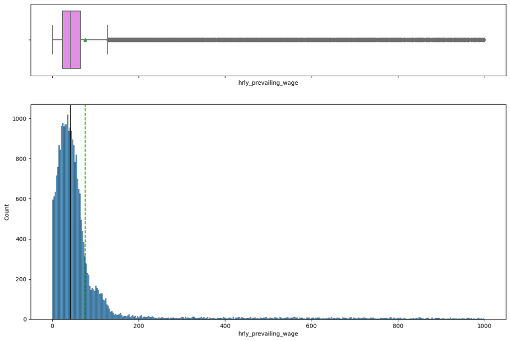

```python
histogram_boxplot(data, "hrly_prevailing_wage")
```

```python
data['hrly_prevailing_wage'].median()
```

```
42.56124
```

#### Observations

- Median hrly_prevailing_wage is 42.56 with many right side outliers
- The conversion appears to be more approporiate than prevailing_wage, which was replaced, as the distribution appears roughly normal but skewed right

## Bivariate Analysis

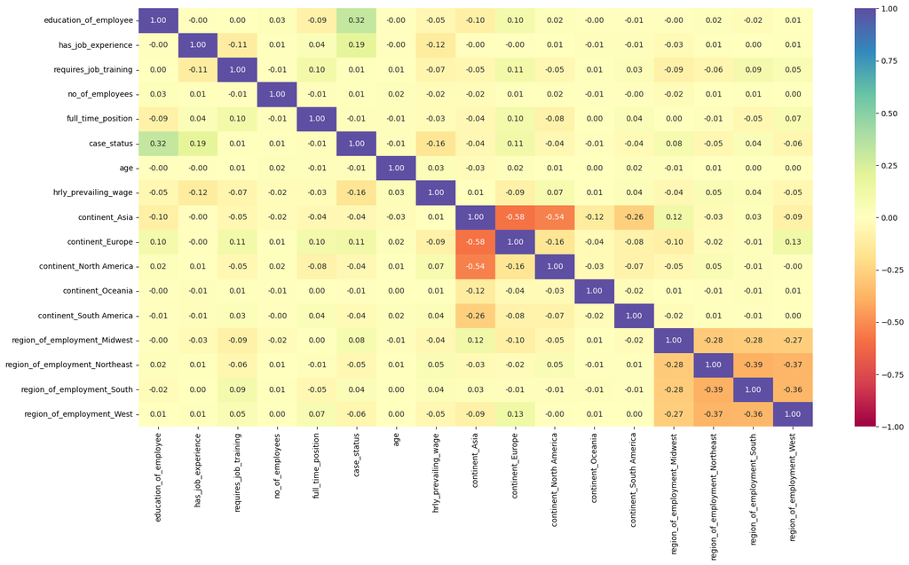

```python
#Re-check correlations including dummy variables
cols_list = data.select_dtypes(include=np.number).columns.tolist()

plt.figure(figsize=(20, 10))
sns.heatmap(data[cols_list].corr(), annot=True, vmin=-1, vmax=1, fmt=".2f", cmap="Spectral")
plt.show()
```

#### Observations

- There are only two correlations with a magnitude over 0.5
  - continent_Europe is negatively correlated with continent_Asia at -0.58
  - continent_North America is negatively correlated with continent_Asia at -0.54
- These negative correlations make sense as continent_Asia is complimentary to continent_Europe and continent_North America

## Final Data Preparation

```python
#Create X (independent variables) and y (dependent variable)
X = data.drop(["case_status"] , axis=1)
y = data[["case_status"]]
```

```python
#Split into test vs. train using a 70:30 ratio
#Use stratify = y to make sure relative class fequencies are approximately the same in the test and train sets
X_train, X_test, y_train, y_test = train_test_split(X, y, test_size=0.30, random_state=1, stratify = y)
```

```python
#Check the shape of X_train, X_test, y_train, and y_test
print("Shape of Training set : ", X_train.shape)
print("Shape of test set : ", X_test.shape)
print("Percentage of classes in training set:")
print(y_train.value_counts(normalize=True))
print("Percentage of classes in test set:")
print(y_test.value_counts(normalize=True))
```

```
Shape of Training set :  (17836, 16)
Shape of test set :  (7644, 16)
Percentage of classes in training set:
case_status
1              0.667919
0              0.332081
dtype: float64
Percentage of classes in test set:
case_status
1              0.667844
0              0.332156
dtype: float64
```

## Model Evaluation

- A false positive (i.e., predicting certified when it should be denied) means a wrong employee will get the job and US employees will miss out on the job opportunity
- A false negative (i.e., predicting denied when it should be certified) means that the right employee will miss out on the job opportunity
- Both cases are sub-optimal - this makes the F1 score the preferred metric for evaluating the models
  - F1 score is greater when recall and precision are higher

```python
#Define a function to compute different metrics to check performance of a classification model

def model_performance_classification_sklearn(model, predictors, target):
    """
    Function to compute different metrics to check classification model performance

    model: classifier
    predictors: independent variables
    target: dependent variable
    """

    # predicting using the independent variables
    pred = model.predict(predictors)

    acc = accuracy_score(target, pred)
    recall = recall_score(target, pred)
    precision = precision_score(target, pred)
    f1 = f1_score(target, pred)

    # creating a dataframe of metrics
    df_perf = pd.DataFrame(
        {"Accuracy": acc, "Recall": recall, "Precision": precision, "F1": f1,},
        index=[0],)

    return df_perf
```

```python
#Define a function for create a confusion matrix

def confusion_matrix_sklearn(model, predictors, target):
    """
    To plot the confusion_matrix with percentages

    model: classifier
    predictors: independent variables
    target: dependent variable
    """
    y_pred = model.predict(predictors)
    cm = confusion_matrix(target, y_pred)
    labels = np.asarray(
        [
            ["{0:0.0f}".format(item) + "\n{0:.2%}".format(item / cm.flatten().sum())]
            for item in cm.flatten()
        ]
    ).reshape(2, 2)

    plt.figure(figsize=(6, 4))
    sns.heatmap(cm, annot=labels, fmt="")
    plt.ylabel("True label")
    plt.xlabel("Predicted label")
```

## Building Bagging and Boosting Models

### Bagging Classifier without Tuning

```python
#Base_estimator for bagging classifier is a decision tree by default
bagging_estimator=BaggingClassifier(random_state=1)
bagging_estimator.fit(X_train,y_train)
```

```
BaggingClassifier(random_state=1)
```

```python
#Performance on the training data
print("Training performance:")
bagging_estimator_train_perf = model_performance_classification_sklearn(bagging_estimator, X_train, y_train)
bagging_estimator_train_perf
```

```
Training performance:
```

|  | Accuracy | Recall | Precision | F1 |
| --- | --- | --- | --- | --- |
| 0 | 0.985535 | 0.98573 | 0.992562 | 0.989134 |

```python
#Performance on the test data
print("Test performance:")
bagging_estimator_test_perf = model_performance_classification_sklearn(bagging_estimator, X_test, y_test)
bagging_estimator_test_perf
```

```
Test performance:
```

|  | Accuracy | Recall | Precision | F1 |
| --- | --- | --- | --- | --- |
| 0 | 0.689168 | 0.769833 | 0.765933 | 0.767878 |

### Bagging Classifier with Hyperparameter Tuning

```python
# Choose the type of classifier.
bagging_estimator_tuned = BaggingClassifier(random_state=1)

# Grid of parameters to choose from
parameters = {
    "max_samples": [0.7, 0.8, 0.9],
    "max_features": [0.7, 0.8, 0.9],
    "n_estimators": np.arange(90, 111, 10),
}

# F1 scoring used to compare parameter combinations
acc_scorer = metrics.make_scorer(metrics.f1_score)

# Run the grid search
grid_obj = GridSearchCV(bagging_estimator_tuned, parameters, scoring=acc_scorer,cv=5)
grid_obj = grid_obj.fit(X_train, y_train)

# Set the clf to the best combination of parameters
bagging_estimator_tuned = grid_obj.best_estimator_

# Fit the best algorithm to the data.
bagging_estimator_tuned.fit(X_train, y_train)
```

```
BaggingClassifier(max_features=0.8, max_samples=0.7, n_estimators=100,
                  random_state=1)
```

```python
#Performance on the training data
print("Training performance:")
bagging_estimator_tuned_train_perf = model_performance_classification_sklearn(bagging_estimator_tuned, X_train, y_train)
bagging_estimator_tuned_train_perf
```

```
Training performance:
```

|  | Accuracy | Recall | Precision | F1 |
| --- | --- | --- | --- | --- |
| 0 | 0.996468 | 0.999916 | 0.994822 | 0.997363 |

```python
#Performance on the test data
print("Test performance:")
bagging_estimator_tuned_test_perf = model_performance_classification_sklearn(bagging_estimator_tuned, X_test, y_test)
bagging_estimator_tuned_test_perf
```

```
Test performance:
```

|  | Accuracy | Recall | Precision | F1 |
| --- | --- | --- | --- | --- |
| 0 | 0.722004 | 0.881293 | 0.747591 | 0.808954 |

#### Observations

- The bagging classifier without tuning appears to overfit the data
  - Train Recall and F1 are 0.986 and 0.989, respectively
  - Test Recall and F1 are 0.770 and 0.768, respectively
- The bagging classifier with tuning also may have some degree of overfitting
  - Train Recall and F1 are 1.000 and 0.997, respectively
  - Test Recall and F1 are 0.881 and 0.809, respectively
- The bagging classifier with tuning performs better on both the training set and test set compaired to the bagging classifier without tuning

### Random Forest Classifier without Tuning

```python
# Fitting the Random Forest Classifier
rf_estimator = RandomForestClassifier(random_state = 1)
rf_estimator.fit(X_train, y_train)
```

```
RandomForestClassifier(random_state=1)
```

```python
#Performance on the training data
print("Train performance:")
rf_estimator_train_perf = model_performance_classification_sklearn(rf_estimator, X_train, y_train)
rf_estimator_train_perf
```

```
Train performance:
```

|  | Accuracy | Recall | Precision | F1 |
| --- | --- | --- | --- | --- |
| 0 | 1.0 | 1.0 | 1.0 | 1.0 |

```python
#Performance on the test data
print("Test performance:")
rf_estimator_test_perf = model_performance_classification_sklearn(rf_estimator, X_test, y_test)
rf_estimator_test_perf
```

```
Test performance:
```

|  | Accuracy | Recall | Precision | F1 |
| --- | --- | --- | --- | --- |
| 0 | 0.717425 | 0.829383 | 0.766612 | 0.796763 |

### Random Forest Classifier with Hyperparameter Tuning

```python
rf_tuned = RandomForestClassifier(random_state=1, oob_score=True, bootstrap=True)

parameters = {
    "max_depth": list(np.arange(5, 15, 5)),
    "max_features": np.arange(0.2, 0.7, 0.1),
    "min_samples_split": [5, 7],
    "n_estimators": np.arange(15, 26, 5),
}

# Type of scoring used to compare parameter combinations
acc_scorer = metrics.make_scorer(metrics.f1_score)

# Run the grid search
grid_obj = GridSearchCV(rf_tuned, parameters, scoring=acc_scorer, cv = 5, n_jobs = -1)
grid_obj = grid_obj.fit(X_train, y_train)

# Set the clf to the best combination of parameters
rf_tuned = grid_obj.best_estimator_

# Fit the best algorithm to the data.
rf_tuned.fit(X_train, y_train)
```

```
RandomForestClassifier(max_depth=10, max_features=0.30000000000000004,
                       min_samples_split=7, n_estimators=25, oob_score=True,
                       random_state=1)
```

```python
#Performance on the training data
print("Train performance:")
rf_tuned_train_perf = model_performance_classification_sklearn(rf_tuned, X_train, y_train)
rf_tuned_train_perf
```

```
Train performance:
```

|  | Accuracy | Recall | Precision | F1 |
| --- | --- | --- | --- | --- |
| 0 | 0.7768 | 0.910434 | 0.788227 | 0.844934 |

```python
#Performance on the test data
print("Test performance:")
rf_tuned_test_perf = model_performance_classification_sklearn(rf_tuned, X_test, y_test)
rf_tuned_test_perf
```

```
Test performance:
```

|  | Accuracy | Recall | Precision | F1 |
| --- | --- | --- | --- | --- |
| 0 | 0.734301 | 0.881293 | 0.759453 | 0.815849 |

#### Observations

- The random forest classifier without tuning appears to overfit the data
  - Train Recall and F1 are 1.000 and 1.000, respectively
  - Test Recall and F1 are 0.829 and 0.797, respectively
- The random forest classifier with tuning appears to not have substantial overfitting
  - Train Recall and F1 are 0.910 and 0.845, respectively
  - Test Recall and F1 are 0.881 and 0.816, respectively
- The random forest classifier with tuning performs better on the test set compaired to the random forest classifier without tuning

### AdaBoost Classifier without Tuning

```python
abc = AdaBoostClassifier(random_state=1)
abc.fit(X_train,y_train)
```

```
AdaBoostClassifier(random_state=1)
```

```python
#Performance on the training data
print("Train performance:")
abc_train_perf = model_performance_classification_sklearn(abc, X_train, y_train)
abc_train_perf
```

```
Train performance:
```

|  | Accuracy | Recall | Precision | F1 |
| --- | --- | --- | --- | --- |
| 0 | 0.732563 | 0.884664 | 0.756297 | 0.81546 |

```python
#Performance on the test data
print("Test performance:")
abc_test_perf = model_performance_classification_sklearn(abc, X_test, y_test)
abc_test_perf
```

```
Test performance:
```

|  | Accuracy | Recall | Precision | F1 |
| --- | --- | --- | --- | --- |
| 0 | 0.729723 | 0.885015 | 0.753377 | 0.813907 |

### AdaBoost Classifier with Hyperparameter Tuning

```python
# Choose the type of classifier.
abc_tuned = AdaBoostClassifier(random_state=1)

# Grid of parameters to choose from
parameters = {
    "base_estimator": [DecisionTreeClassifier(max_depth=1, random_state=1),
        DecisionTreeClassifier(max_depth=2, random_state=1)],
    "n_estimators": np.arange(80, 101, 10),
    "learning_rate": np.arange(0.1, 0.4, 0.1),
}

# Type of scoring used to compare parameter  combinations
acc_scorer = metrics.make_scorer(metrics.f1_score)

# Run the grid search
grid_obj = GridSearchCV(abc_tuned, parameters, scoring=acc_scorer, cv = 5)
grid_obj = grid_obj.fit(X_train, y_train)

# Set the clf to the best combination of parameters
abc_tuned = grid_obj.best_estimator_

# Fit the best algorithm to the data.
abc_tuned.fit(X_train, y_train)
```

```
AdaBoostClassifier(base_estimator=DecisionTreeClassifier(max_depth=2,
                                                         random_state=1),
                   learning_rate=0.1, n_estimators=90, random_state=1)
```

```python
#Performance on the training data
print("Train performance:")
abc_tuned_train_perf = model_performance_classification_sklearn(abc_tuned, X_train, y_train)
abc_tuned_train_perf
```

```
Train performance:
```

|  | Accuracy | Recall | Precision | F1 |
| --- | --- | --- | --- | --- |
| 0 | 0.743608 | 0.880886 | 0.768904 | 0.821095 |

```python
#Performance on the test data
print("Test performance:")
abc_tuned_test_perf = model_performance_classification_sklearn(abc_tuned, X_test, y_test)
abc_tuned_test_perf
```

```
Test performance:
```

|  | Accuracy | Recall | Precision | F1 |
| --- | --- | --- | --- | --- |
| 0 | 0.733124 | 0.874829 | 0.761207 | 0.814072 |

#### Observations

- The AdaBoost classifier without tuning does not appear to overfit the data
  - Train Recall and F1 are 0.885 and 0.815, respectively
  - Test Recall and F1 are 0.885 and 0.814, respectively
- The AdaBoost classifier with hyperparameter tuning does not appear to overfit the data
  - Train Recall and F1 are 0.881 and 0.821, respectively
  - Test Recall and F1 are 0.875 and 0.814, respectively
- The AdaBoost classifier with hyperparameter tuning performs as well on the test data as the AdaBoost classifier without tuning

### Gradient Boosting Classifier without Tuning

```python
gbc = GradientBoostingClassifier(random_state=1)
gbc.fit(X_train, y_train)
```

```
GradientBoostingClassifier(random_state=1)
```

```python
#Performance on the training data
print("Train performance:")
gbc_train_perf = model_performance_classification_sklearn(gbc, X_train, y_train)
gbc_train_perf
```

```
Train performance:
```

|  | Accuracy | Recall | Precision | F1 |
| --- | --- | --- | --- | --- |
| 0 | 0.752187 | 0.881978 | 0.777087 | 0.826217 |

```python
#Performance on the test data
print("Test performance:")
gbc_test_perf = model_performance_classification_sklearn(gbc, X_test, y_test)
gbc_test_perf
```

```
Test performance:
```

|  | Accuracy | Recall | Precision | F1 |
| --- | --- | --- | --- | --- |
| 0 | 0.736133 | 0.874241 | 0.764474 | 0.815681 |

### Gradient Boosting Classifier with Hyperparameter Tuning

```python
gbc_tuned = GradientBoostingClassifier(init=AdaBoostClassifier(random_state=1), random_state=1)

# Grid of parameters to choose from
parameters = {
    "n_estimators": [200, 250],
    "subsample": [0.9, 1],
    "max_features": [0.8, 0.9],
    "learning_rate": np.arange(0.1, 0.21, 0.1),
}

# Type of scoring used to compare parameter combinations
acc_scorer = metrics.make_scorer(metrics.f1_score)

# Run the grid search
grid_obj = GridSearchCV(gbc_tuned, parameters, scoring=acc_scorer, cv = 5)
grid_obj = grid_obj.fit(X_train, y_train)


# Set the clf to the best combination of parameters
gbc_tuned = grid_obj.best_estimator_

# Fit the best algorithm to the data.
gbc_tuned.fit(X_train, y_train)
```

```
GradientBoostingClassifier(init=AdaBoostClassifier(random_state=1),
                           max_features=0.9, n_estimators=200, random_state=1,
                           subsample=0.9)
```

```python
#Performance on the training data
print("Train performance:")
gbc_tuned_train_perf = model_performance_classification_sklearn(gbc_tuned, X_train, y_train)
gbc_tuned_train_perf
```

```
Train performance:
```

|  | Accuracy | Recall | Precision | F1 |
| --- | --- | --- | --- | --- |
| 0 | 0.76183 | 0.885335 | 0.78539 | 0.832373 |

```python
#Performance on the test data
print("Test performance:")
gbc_tuned_test_perf = model_performance_classification_sklearn(gbc_tuned, X_test, y_test)
gbc_tuned_test_perf
```

```
Test performance:
```

|  | Accuracy | Recall | Precision | F1 |
| --- | --- | --- | --- | --- |
| 0 | 0.738749 | 0.870127 | 0.769044 | 0.816469 |

#### Observations

- The Gradient Boosting Classifier without tuning does not appear to overfit the data
  - Train Recall and F1 are 0.882 and 0.826, respectively
  - Test Recall and F1 are 0.874 and 0.816, respectively
- The Gradient Boosting Classifier with hyperparameter tuning does not appear to overfit the data
  - Train Recall and F1 are 0.885 and 0.832, respectively
  - Test Recall and F1 are 0.870 and 0.816, respectively
- The Gradient Boosting Classifier with hyperparameter tuning performs as well on the test data as the Gradient Boosting Classifier without tuning

### XGBoost Classifier without Tuning

```python
xgb = XGBClassifier(random_state=1,eval_metric='logloss')
xgb.fit(X_train,y_train)
```

```
XGBClassifier(base_score=None, booster=None, callbacks=None,
              colsample_bylevel=None, colsample_bynode=None,
              colsample_bytree=None, device=None, early_stopping_rounds=None,
              enable_categorical=False, eval_metric='logloss',
              feature_types=None, gamma=None, grow_policy=None,
              importance_type=None, interaction_constraints=None,
              learning_rate=None, max_bin=None, max_cat_threshold=None,
              max_cat_to_onehot=None, max_delta_step=None, max_depth=None,
              max_leaves=None, min_child_weight=None, missing=nan,
              monotone_constraints=None, multi_strategy=None, n_estimators=None,
              n_jobs=None, num_parallel_tree=None, random_state=1, ...)
```

```python
#Performance on the training data
print("Train performance:")
xgb_train_perf = model_performance_classification_sklearn(xgb, X_train, y_train)
xgb_train_perf
```

```
Train performance:
```

|  | Accuracy | Recall | Precision | F1 |
| --- | --- | --- | --- | --- |
| 0 | 0.848845 | 0.935365 | 0.852628 | 0.892082 |

```python
#Performance on the test data
print("Test performance:")
xgb_test_perf = model_performance_classification_sklearn(xgb, X_test, y_test)
xgb_test_perf
```

```
Test performance:
```

|  | Accuracy | Recall | Precision | F1 |
| --- | --- | --- | --- | --- |
| 0 | 0.723836 | 0.8476 | 0.764488 | 0.803902 |

### XGBoost Classifier with Hyperparameter Tuning

```python
# Choose the type of classifier.
xgb_tuned = XGBClassifier(random_state=1, eval_metric="logloss")

# Grid of parameters to choose from
parameters = {"n_estimators": np.arange(150, 250, 50),
    "scale_pos_weight": [1, 2],
    "subsample": [0.9, 1],
    "learning_rate": np.arange(0.1, 0.21, 0.1),
    "gamma": [3, 5],
    "colsample_bytree": [0.8, 0.9],
    "colsample_bylevel": [ 0.9, 1],}

# Type of scoring used to compare parameter combinations
acc_scorer = metrics.make_scorer(metrics.f1_score)

# Run the grid search
grid_obj = GridSearchCV(xgb_tuned, parameters, scoring=acc_scorer, cv = 5)
grid_obj = grid_obj.fit(X_train, y_train)

# Set the clf to the best combination of parameters
xgb_tuned = grid_obj.best_estimator_

# Fit the best algorithm to the data.
xgb_tuned.fit(X_train, y_train)
```

```
XGBClassifier(base_score=None, booster=None, callbacks=None,
              colsample_bylevel=0.9, colsample_bynode=None,
              colsample_bytree=0.8, device=None, early_stopping_rounds=None,
              enable_categorical=False, eval_metric='logloss',
              feature_types=None, gamma=5, grow_policy=None,
              importance_type=None, interaction_constraints=None,
              learning_rate=0.1, max_bin=None, max_cat_threshold=None,
              max_cat_to_onehot=None, max_delta_step=None, max_depth=None,
              max_leaves=None, min_child_weight=None, missing=nan,
              monotone_constraints=None, multi_strategy=None, n_estimators=150,
              n_jobs=None, num_parallel_tree=None, random_state=1, ...)
```

```python
#Performance on the training data
print("Train performance:")
xgb_tuned_train_perf = model_performance_classification_sklearn(xgb_tuned, X_train, y_train)
xgb_tuned_train_perf
```

```
Train performance:
```

|  | Accuracy | Recall | Precision | F1 |
| --- | --- | --- | --- | --- |
| 0 | 0.757345 | 0.881726 | 0.782537 | 0.829176 |

```python
#Performance on the test data
print("Test performance:")
xgb_tuned_test_perf = model_performance_classification_sklearn(xgb_tuned, X_test, y_test)
xgb_tuned_test_perf
```

```
Test performance:
```

|  | Accuracy | Recall | Precision | F1 |
| --- | --- | --- | --- | --- |
| 0 | 0.740973 | 0.872674 | 0.770095 | 0.818182 |

#### Observations

- The XGB Classifier without tuning may be overfitting the data
  - Train Recall and F1 are 0.935 and 0.892, respectively
  - Test Recall and F1 are 0.848 and 0.804, respectively
- The XGB Classifier with hyperparameter tuning does not appear to overfit the data
  - Train Recall and F1 are 0.882 and 0.829, respectively
  - Test Recall and F1 are 0.873 and 0.818, respectively
- The XGB Classifier with hyperparameter tuning performs better on the test data relative to the XGB Classifier without tuning

### Stacking Classifier

```python
estimators = [('AdaBoost', abc_tuned ),
              ('Gradient Boosting', gbc_tuned ),
              ('Random Forest', rf_tuned)]

final_estimator = xgb_tuned

SC = StackingClassifier(estimators=estimators,final_estimator=xgb_tuned)
SC.fit(X_train, y_train)
```

```
StackingClassifier(estimators=[('AdaBoost',
                                AdaBoostClassifier(base_estimator=DecisionTreeClassifier(max_depth=2,
                                                                                         random_state=1),
                                                   learning_rate=0.1,
                                                   n_estimators=90,
                                                   random_state=1)),
                               ('Gradient Boosting',
                                GradientBoostingClassifier(init=AdaBoostClassifier(random_state=1),
                                                           max_features=0.9,
                                                           n_estimators=200,
                                                           random_state=1,
                                                           subsample=0.9)),
                               ('Random Forest',
                                Ran...
                                                 feature_types=None, gamma=5,
                                                 grow_policy=None,
                                                 importance_type=None,
                                                 interaction_constraints=None,
                                                 learning_rate=0.1,
                                                 max_bin=None,
                                                 max_cat_threshold=None,
                                                 max_cat_to_onehot=None,
                                                 max_delta_step=None,
                                                 max_depth=None,
                                                 max_leaves=None,
                                                 min_child_weight=None,
                                                 missing=nan,
                                                 monotone_constraints=None,
                                                 multi_strategy=None,
                                                 n_estimators=150, n_jobs=None,
                                                 num_parallel_tree=None,
                                                 random_state=1, ...))
```

```python
#Performance on the training data
print("Train performance:")
SC_train_perf = model_performance_classification_sklearn(SC, X_train, y_train)
SC_train_perf
```

```
Train performance:
```

|  | Accuracy | Recall | Precision | F1 |
| --- | --- | --- | --- | --- |
| 0 | 0.771754 | 0.889868 | 0.793488 | 0.838919 |

```python
#Performance on the test data
print("Test performance:")
SC_test_perf = model_performance_classification_sklearn(SC, X_test, y_test)
SC_test_perf
```

```
Test performance:
```

|  | Accuracy | Recall | Precision | F1 |
| --- | --- | --- | --- | --- |
| 0 | 0.737703 | 0.870127 | 0.767981 | 0.815869 |

#### Observations

- The Stacking Classifier does not appear to overfit the data
  - Train Recall and F1 are 0.890 and 0.839, respectively
  - Test Recall and F1 are 0.870 and 0.816, respectively

## Model Performance Comparison and Conclusions

#### Observations

- For the Bagging Classifier, performance on the test set is better using the tuned model
  - The untuned model on test data has an F1 of 0.768
  - The tuned model on test data has an F1 of 0.809
  - The bagging classifier with tuning performs better on both the training set and test set compaired to the bagging classifier without tuning
- For the Random Forest classifier, performance on the test set is better using the tuned model
  - The untuned model on test data has an F1 of 0.797
  - The tuned model on test data has an F1 of 0.816
  - The random forest classifier with tuning performs better on the test set compaired to the random forest classifier without tuning
- For the AdaBoost classifier, performance on the test set is as good for the tuned model as it is for the untuned model
  - The untuned model on test data has an F1 of 0.814
  - The tuned model on the test data has an F1 of 0.814
- For the Gradient Boosting classifier, performance on the test set is as good for the tuned model as it is for the untuned model
  - The untuned model on the test data has an F1 of 0.816
  - The tuned model on the test data has an F1 of 0.816
- For the XG Boosting classifier, performance on the test set is better using the tuned model
  - The untuned model on the test data has an F1 of 0.804
  - The tuned model on the test data has an F1 of 0.818
  - The XB Boosting Classifier with tuning performs slightly better on the test set compared to the XB Boosting Classifier without tuning
- For the Stacking Classifier, peformance on the test set is similar to performance on the training set
  - F1 on the training data is 0.839
  - F1 on the test data is 0.816

### Important Features on the Final Model

- The model with the best performance is the tuned XG Boosting Classifier with an F1 on the test set of 0.818

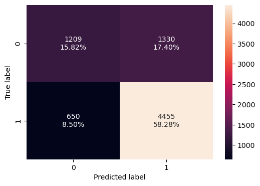

```python
confusion_matrix_sklearn(xgb_tuned, X_test, y_test)
```

```python
#Performance on the test data
print("Test performance:")
xgb_tuned_test_perf = model_performance_classification_sklearn(xgb_tuned, X_test, y_test)
xgb_tuned_test_perf
```

```
Test performance:
```

|  | Accuracy | Recall | Precision | F1 |
| --- | --- | --- | --- | --- |
| 0 | 0.740973 | 0.872674 | 0.770095 | 0.818182 |

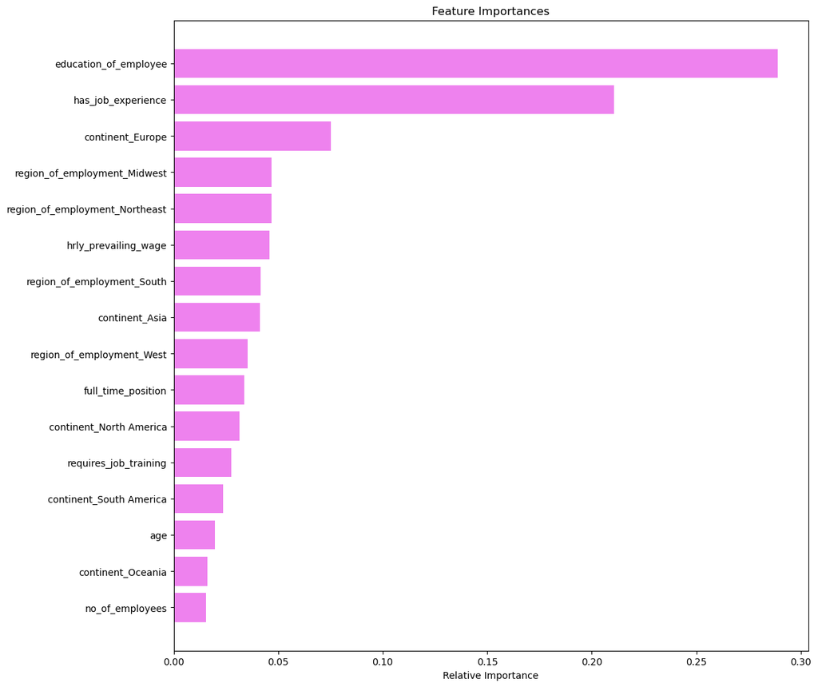

```python
#Feature importances
feature_names = X_train.columns
importances = xgb_tuned.feature_importances_
indices = np.argsort(importances)

plt.figure(figsize=(12, 12))
plt.title("Feature Importances")
plt.barh(range(len(indices)), importances[indices], color="violet", align="center")
plt.yticks(range(len(indices)), [feature_names[i] for i in indices])
plt.xlabel("Relative Importance")
plt.show()
```

## Actionable Insights and Recommendations

### Final Model Selection Criteria

- The final model is the one with the best F1 on the test data, which is the tuned XG Boosting model
  - F1 was selected since true positive rate and precision are considered equally important
  - F1 reflects both recall (TP / (TP + FN)) and precision (TP / (TP + FP))
- A `Cost Function` quantifies the error between predicted values and expected values and presents it in the form of a single real number.
- We can chose a model depending on the cost function we want to minimize
  - Certifying an employee that should not have been can negatively impact efficiency as a suboptimal employee is allowed
  - Not certifiying an employee that should have been can also negatively impact efficiency, as an optimal employee is not allowed
- The main aim would be to balance the trade off between the recall and precision, so the F1 statistic is maximized
- education_of_employee, has_job_experience, and continent_Europe are found to be the three most important features in the final model
  - Employees with advanced degrees are more likely to be certified
  - Employees with only high school education are less likely to be certified
- The model correctly identifies 87.3% of employees that are certified (true positive rate)
- However, the model only correctly identifies 47.6% of employees that are not certified (true negative rate)
- Based on the analysis, it can be concluded that the certification rate is higher given:
  - More advanced education
  - Having prior job experience
  - Employee is from Europe
  - Region of employment is Midwest
  - Lower hourly prevailing wage

### Factors Influencing Short-Listing of Potential Employees and Corresponding Employer Implications

- Employees with higher education levels should be more likely to be short-listed
  - Employees with high school education, in particular, are less likely to be certified
- Employees with job experience should also be more likely to be short-listed
  - Employers should focus on hiring employees with job experience
- Employees from Europe should also be somewhat more likely to be short-listed
- Employees being considered for employment in the Midwest should also be more likely to be short-listed
- A greater hourly prevailing wage should make it less likely for the employee to be short-listed
  - Higher prevailing wages can make it more difficult to be certified as employers are required to pay higher market wages
- Company age and number of employees are neither found to be highly important in determining short-listed employees
- Employees requirement of job training is also not found to be highly important in determining short-listing employees
  - This feature may be made less important as it is likely related to prior job experience, which is an important feature in determining which employees should be short-listed